# 826 Homework 2

Noah Stafford

2/26/2020

## A.

To replicate the first row of table 2, the variables in the model need to be located. We need the subject, visit number, randomization group, and symptom days over a two-week period. According to the code book, these variables are coded as:

- ID – Unique identifier – 5 digit number
- VisitNum – visit number – 0: baseline ; 1: 3month; 2: 6month ; 3: 9month ; 4: 12month
- group – randomization group – ‘Education’, ‘IPM’
- sxsmaxday – maximum symptom days of 3 symptom counts: general, slowed, nightcnt - [0-14]

```
## # A tibble: 2 x 4
##   group     `Maximal symptom days/2 wk median` `25% IQR` `75% IQR`
##   <fct>                                  <dbl>     <dbl>     <dbl>
## 1 Education                                2.7       1.3       5
## 2 IPM                                      2         0.7       4.7
```

```
## [1] "Ratio of Symptom Frequencies"
```

```
## [1] 0.86
```

```
## [1] "95% Confidence Interval"
```

```
## [1] "0.69 to 1.06"
```

# B.

```
## [1] "Ratio of Symptom Frequencies"
```

```
## [1] 0.86
```

```
## [1] "95% Confidence Interval"
```

```
## [1] "0.69 to 1.07"
```

# C.

From reading the paper, I found that the main analysis left resulted in an unsatisfactory conclusion, while the exploratory analysis demonstrated that the effect the investigators were looking for likely exists – finding it was just elusive due to how the study was designed and due to the high reduction in allergens in the environment among the education only group.

To outline this issue, I binned the bedroom mouse allergen data into percentiles (based on the distribution of this variable across the entire data set), and then plotted a percent stacked barplot comparing the distribution of the percentiles of bedroom mouse allergen for each visit number between the experimental groups. As can be seen, there was a similar reduction in allergen levels across both groups, though the reduction in the IPM group appears to be somewhat larger.

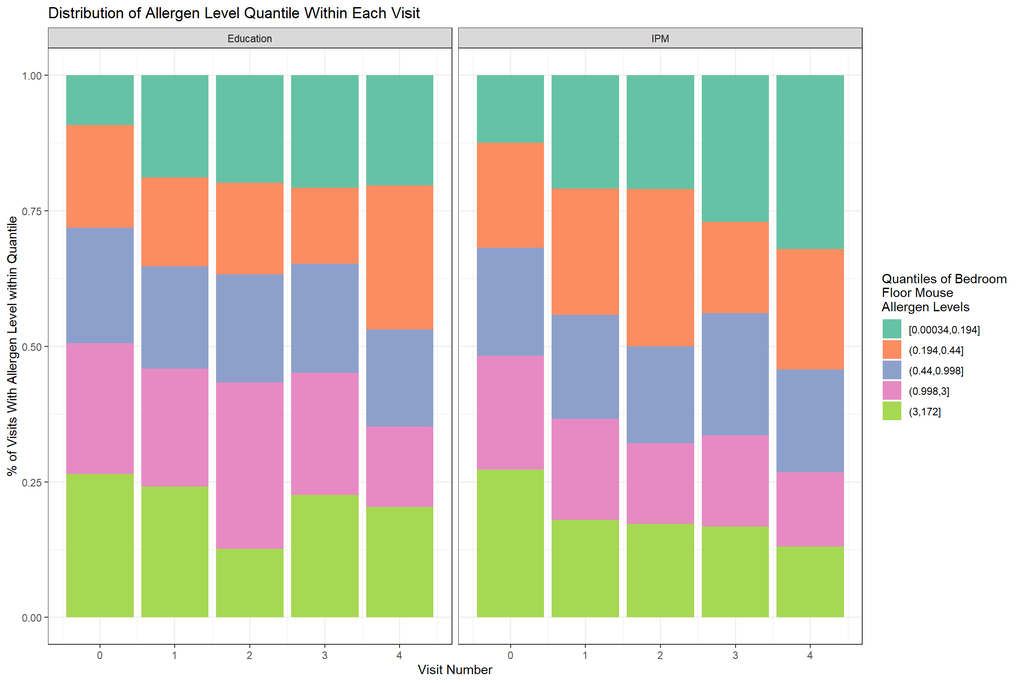

Perhaps the inconclusiveness of the primary analysis is less a commentary on the insignificant effect of mouse allergens on asthma, and more a demonstration that educating people on how to get rid of rodents is pretty effecive at getting them to do it themselves.

The next two charts demonstrate the lack of separation between the two groups when you compare them on the outcome variable, number of asthma symptom days in the past two weeks.

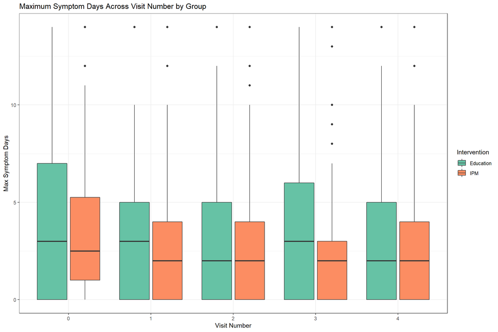

Here, I looked to visualize the data by patient. I binned the data into baseline (visits 0 and 1), and follow-up (visits 2,3,4). I calculated the mean symptom days within each of these two groups, and took their difference. This adjusts within each patient for pre-existing asthma conditions. If either of the groups contributed to a decrease, or prevented an increase in asthma symptom days, the peaks of the histograms should be offset. In short, they are not.

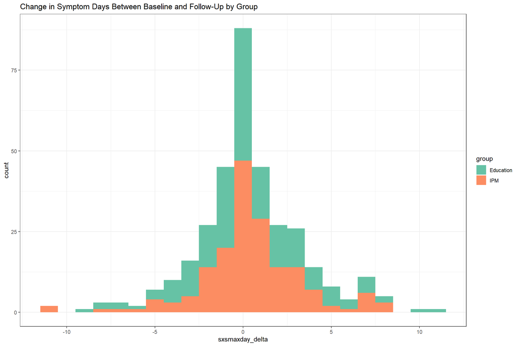

Here is a table to drive the point home, simplifying the above distribution into three bins and comparing the frequencies the data is in each bin across the two groups. There is very little difference in the frequencies.

```
## # A tibble: 2 x 4
##   group   `Change < 2 Days from ~ `Change Within 2 Days ~ `Change > 2 Days from~
##   <fct>                     <dbl>                   <dbl>                  <dbl>
## 1 Educat~                    0.18                   0.570                   0.24
## 2 IPM                        0.14                   0.62                    0.23
```

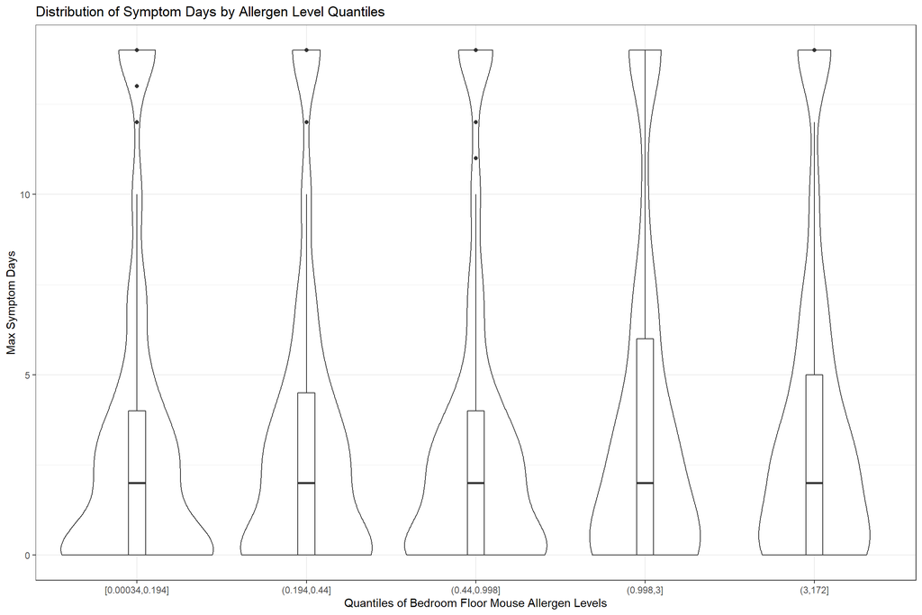

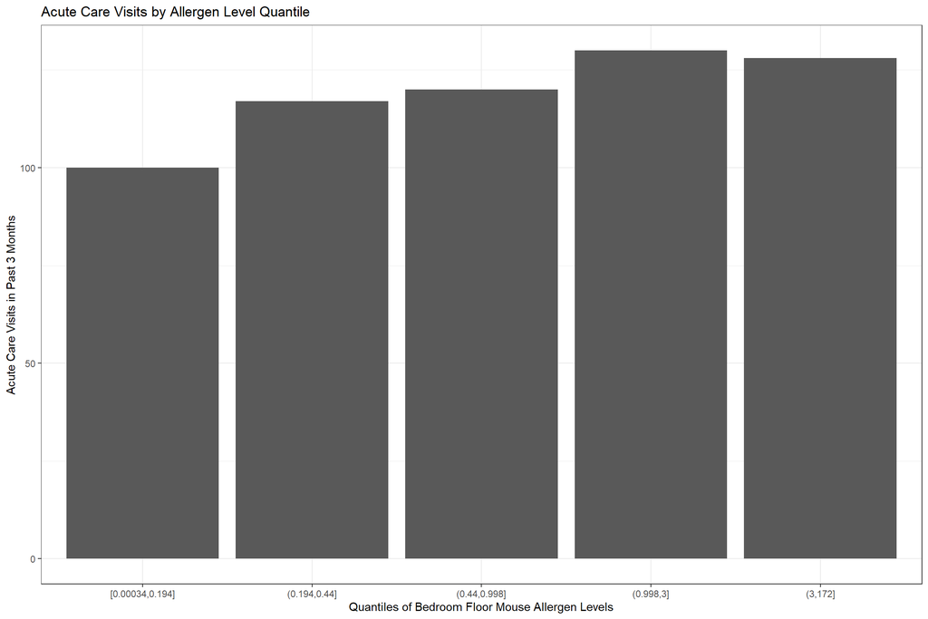

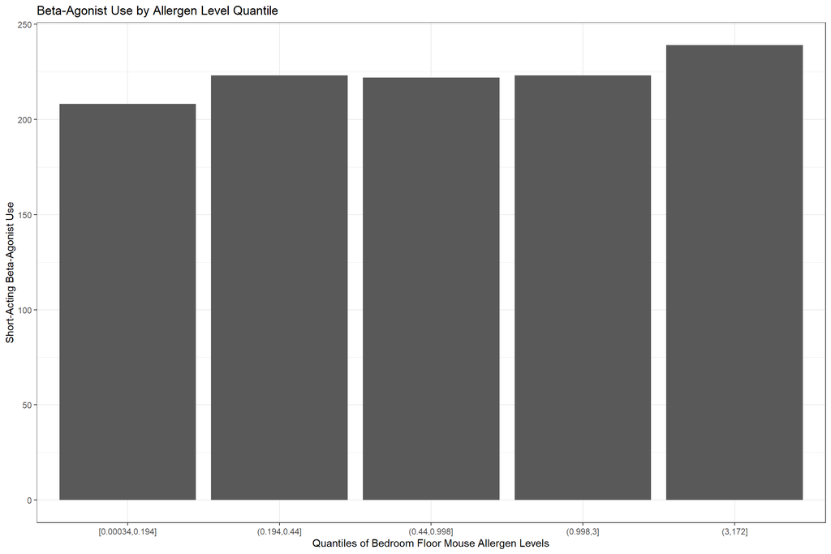

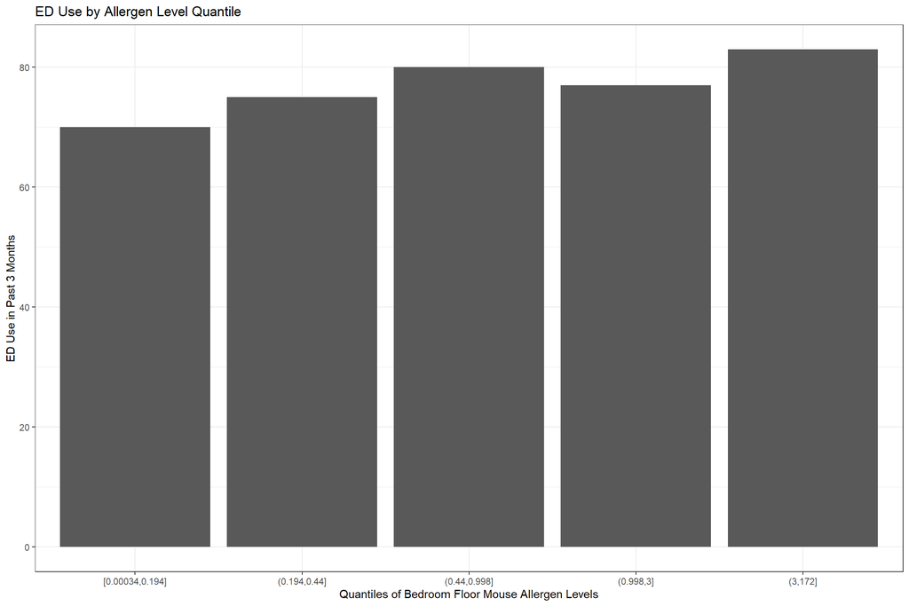

No conclusive statements can be made about these effects, as time and individual effects are being ignored, and these is no randomization when looking at the data this way, so many unknown covariates could be the actual cause of these trends. But these trends demonstrate that there is possibly an association here, and the issue warrants more investigation through a better-designed or more focused study.

# D.

I split the figure up into plotting the medians and plotting the ratios of symptom frequencies separately, becasuse they are different statistics and thus on a different scale. Since I wanted to do some clean, nifty multi-plots it was much simpler to do these plots separately. Next, I wanted to prioriztize the comparison between groups of each statistic and their IQRs. To do this, each median should be plotted side-by-side with the other median of the same variable from the other group. To keep things clean, I used the faced_wrap() function to split the plot into subplots per variable. This condensed the y-axis some but not to a point where information is obscured. The main disadvantage of this plot is that you can’t compare the magnitude of each statistic across variables easily. I tried to put all the plots in one row but the labels got cut off. In a context where more width is allowed having one row is the best option. I opted to make the median bars red and the IQR bars black and smaller than the median bars to emphasize the importance of the medians.

The plot of the ratios is much the same, except the data was not split on the experimental groups anymore, so there was no reason to take that into account, and the layout could be simplified.

I usually change the ggplot theme because I think the default one looks kinda crappy.

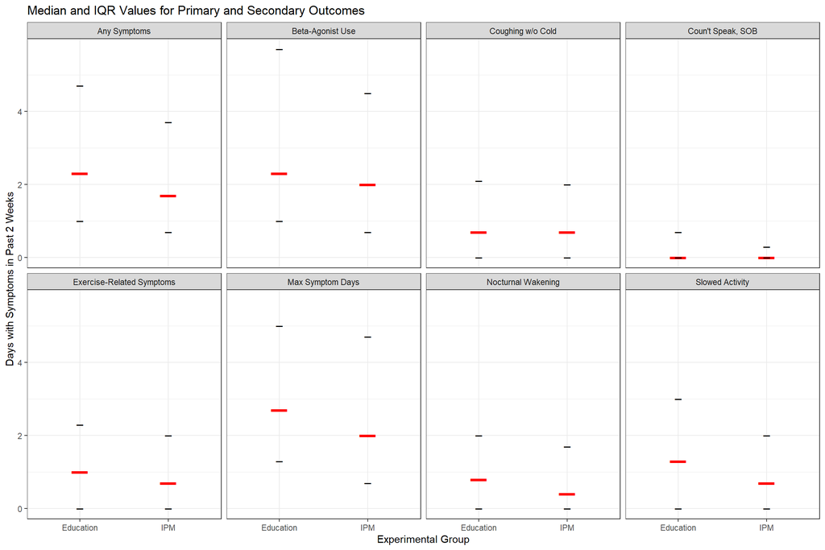

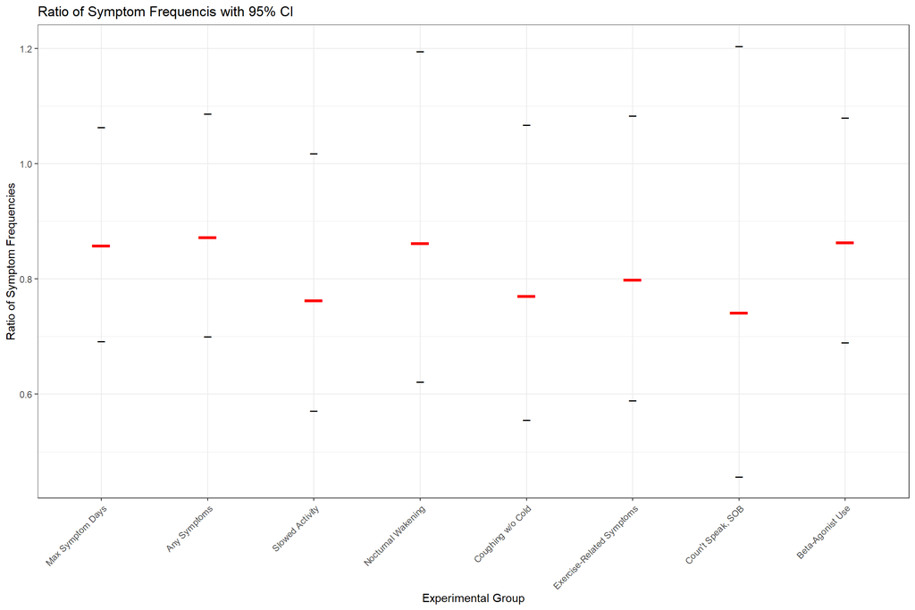